Skip to main content

REDCap starter kit

Portfolio project · R · REDCap · Quarto

# REDCap starter kit. From REDCap project to quality-checked report.

This kit pulls records from REDCap with REDCapR, uses the project's own data dictionary to drive cleaning and labelling, runs six data quality checks, and renders the status report below. It is demonstrated on a fictional pregnancy cohort with synthetic data.

Read the sample report [Code on GitHub](https://github.com/emmabranch/redcap-starter-kit)

Background: one stripe per week of enrolment in the sample study, brighter in busier weeks.

# Coastal Beginnings Study

Data status and quality report

A fictional pregnancy cohort. All data are simulated.

Author

Emma Branch

Published

November 21, 2026

[figure not shown]

**Note**

This report is generated automatically from a REDCap project by the [REDCap starter kit](https://github.com/emmabranch/redcap-starter-kit). The study and every record in it are fictional, simulated for demonstration.

## At a glance

301

participants enrolled

88%

completed the third trimester survey

97%

have a birth outcome recorded

20

data issues to resolve, in 18 records

## Recruitment

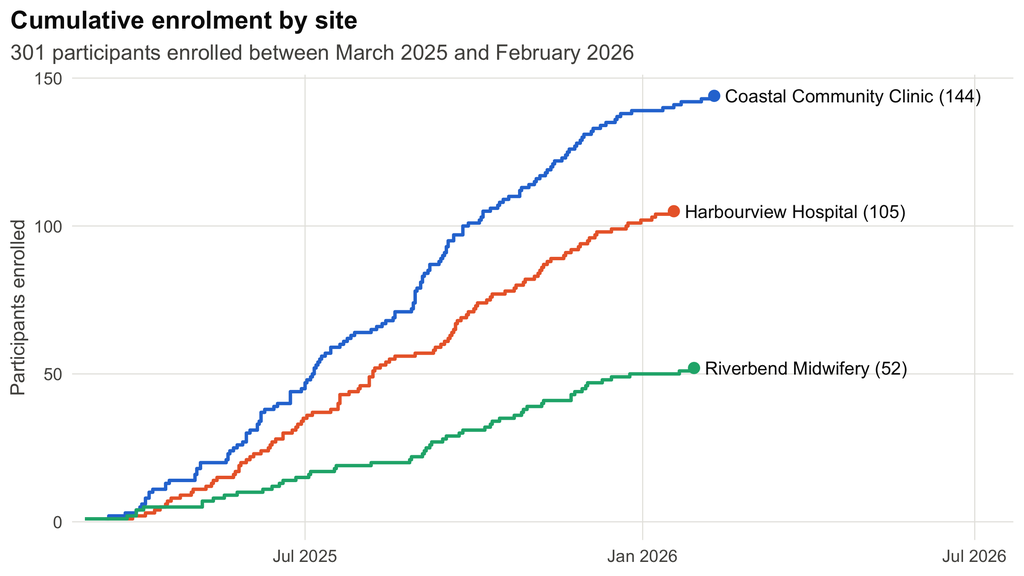

## Follow-up and form completion

| Event | Records | Share of enrolled | Form status Complete | Form status Unverified | Form status Incomplete |
| --- | --- | --- | --- | --- | --- |
| Enrolment | 301 | 100% | 249 | 49 | 3 |
| Third trimester survey | 266 | 88% | 218 | 47 | 1 |
| Birth outcome | 291 | 97% | 248 | 41 | 2 |

Form status is set by data entry staff in REDCap. Incomplete forms usually have a required field left blank.

## Data quality

The quality checks flagged **20 issues** in **18 records**. This synthetic dataset has 18 problems planted on purpose, and the checks caught **18 of 18**. The extra flags are knock-on effects: one wrong date can trip more than one check.

| Check | Issues | What it means |
| --- | --- | --- |
| Branching logic violation | 3 | A value sits in a question that should be hidden |
| Date order | 3 | Dates across events are in an impossible order |
| Implausible gestational age | 3 | Gestational age at birth outside 22 to 44 weeks |
| Missing required field | 6 | A required question was left blank |
| Out of range | 4 | Value outside the limits set in the data dictionary |
| Possible duplicate | 1 | Same person may be enrolled twice |

### Issues to resolve

The full list, ready to send to the study coordinator. It is also saved as `outputs/qc_issues.csv`.

| Record | Event | Question | Value | Check | Detail |
| --- | --- | --- | --- | --- | --- |
| 1006 | Enrolment | Cigarettes per day on average | 5 | Branching logic violation | Has a value but should be hidden (shown only if [smoking] = '2') |
| 1018 | Birth | Birth weight (grams) | (blank) | Missing required field | Required field is blank |
| 1020 | Birth | Days in NICU | 3 | Branching logic violation | Has a value but should be hidden (shown only if [nicu] = '1') |
| 1028 | Birth | Birth weight (grams) | (blank) | Missing required field | Required field is blank |
| 1033 | Third trimester | Today's date | 2025-11-30 then 2025-11-16 | Date order | birth_date is before tt_date |
| 1088 | Birth | Birth weight (grams) | 34500 | Out of range | Allowed range 300 to 6000 |
| 1093 | Enrolment | Number of previous births at 20 weeks or more | (blank) | Missing required field | Required field is blank |
| 1147 | Enrolment | Number of previous births at 20 weeks or more | (blank) | Missing required field | Required field is blank |
| 1162 | Third trimester | Have you been diagnosed with gestational diabetes in this pregnancy? | (blank) | Missing required field | Required field is blank |
| 1163 | Birth | Gestational age at birth (weeks) | 46 | Implausible gestational age | Gestational age at birth outside 22 to 44 weeks; check the LMP and birth dates |

[output cut: 10 more lines]

## Participants at enrolment

Values are shown as entered. Records with open data issues are included, so a few figures may change once those are resolved.

|  | Participants | Age, mean (SD) | BMI, median | First pregnancy | Currently smokes | Bachelor's degree or higher |
| --- | --- | --- | --- | --- | --- | --- |
| Coastal Community Clinic | 144 | 30.8 (5.4) | 26.0 | 49% | 7% | 47% |
| Harbourview Hospital | 105 | 32.0 (4.8) | 26.4 | 49% | 9% | 51% |
| Riverbend Midwifery | 52 | 31.0 (4.5) | 24.8 | 52% | 8% | 60% |

## Birth outcomes

Records flagged with an implausible gestational age or an out-of-range birth weight are left out of these figures until they are corrected.

[figure not shown]

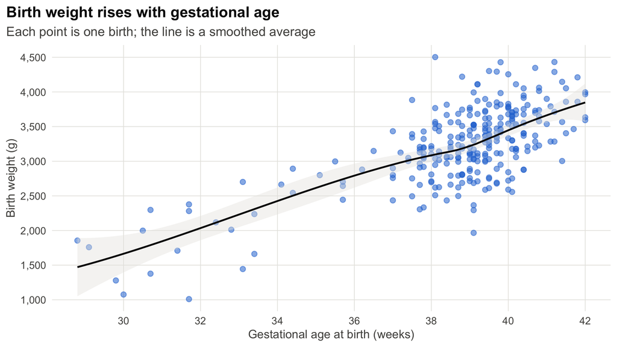

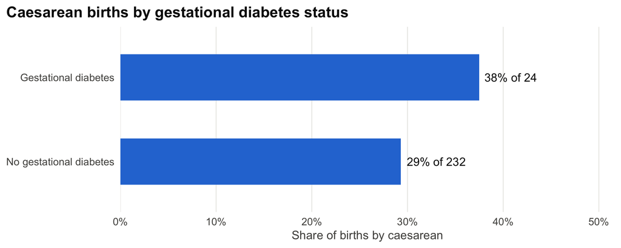